# Transit Trips and Transportation Costs – County

Author

Tina Chelidze and Aaron R. Williams

Published

March 6, 2025

Abstract

This script calculates `share_transportation_cost` and `share_transit_commuter` using Center for Neighborhood Technology (CNT) and Census Bureau data.

**Tip**

Raw CNT data pulled from https://htaindex.cnt.org/download/.

1. Navigate to the data download page.
2. Select “County”.
3. Download the data for all counties.

To save time, we store data on Box in Metrics_2024_round/. See details under the Read Data section.*

## Setup

### Load Packages

```r
library(tidyverse)
library(tidycensus)
library(here)

source(here("functions", "testing", "evaluate_final_data.R"))

theme_set(theme_minimal())

options(scipen = 999)
```

### Read data

Before running, please download the files below from the following [Box folder](https://urbanorg.app.box.com/folder/250262697073) into the repository folder `"mobility-from-poverty/06_neighborhoods/transportation/data/"`

- htaindex2015_data_counties.csv
- htaindex2019_data_counties.csv
- htaindex2022_data_counties.csv

Import all the files (and/or combine into one file) with only the relevant variables and years

```r
read_transportation_data <- function(year) {

  data <- read_csv(
    here("06_neighborhoods",
         "Transportation",
         "data",
         str_glue("htaindex{year}_data_counties.csv"))
  ) |>
    mutate(year = year)

  return(data)

}

transport_county <- map_dfr(
  .x = c(2015, 2019, 2022),
  .f = read_transportation_data
)
```

## Clean Data

Create correct FIPS variables.

```r
transport_county <- transport_county |>
  mutate(
    state = substr(county, start = 2, stop = 3),
    county = substr(county, start = 4, stop = 6)
  )
```

```r
transportation_county <- transport_county |>
  select(year, state, county, blkgrps, population, households, pct_transit_commuters_80ami, t_80ami)
```

Load our target counties file to compare the transportation counties to the counties we need for 2015, 2019, and 2022.

```r
counties <- read_csv(
  here("geographic-crosswalks", "data", "county-populations.csv")
) |>
  filter(year %in% c(2015, 2019, 2022))
```

Test the counties.

```r
stopifnot(
  full_join(transportation_county, counties, by = c("year", "state", "county")) |>
    nrow() ==
  nrow(counties)
)

stopifnot(
  anti_join(transportation_county, counties, by = c("year", "state", "county")) |>
    nrow() == 0
)
```

As shown by `full_join()` and `anti_join()`, the transportation data contain the counties included in the target counties file, so we don’t need to merge the data.

```r
transportation_county <- transportation_county |>
  rename(
    share_transit_commuter = pct_transit_commuters_80ami,
    share_transportation_cost = t_80ami
  )
```

We transform transportation cost from an unlabeled percentage to a proportion.

```r
transportation_county <- transportation_county |>
  mutate(
    share_transit_commuter = share_transit_commuter / 100,
    share_transportation_cost = share_transportation_cost / 100
  )
```

## Transit Trips Quality Control Checks

### Missing Data

```r
transportation_county |>
  filter(is.na(share_transit_commuter))
```

```
# A tibble: 1 × 8
   year state county blkgrps population households share_transit_commuter
  <dbl> <chr> <chr>    <dbl>      <dbl>      <dbl>                  <dbl>
1  2015 48    301          1        117         45                     NA
# ℹ 1 more variable: share_transportation_cost <dbl>
```

Loving County, Texas is missing in 2015.

### Distribution

Use stopifnot to check if all values in `transportation_county` are non-negative

```r
stopifnot(min(transportation_county$share_transit_commuter, na.rm = TRUE) >= 0)
```

Create a histogram plot and summary stats for each dataframe check that all values are non-negative & count missing values examine outliers.

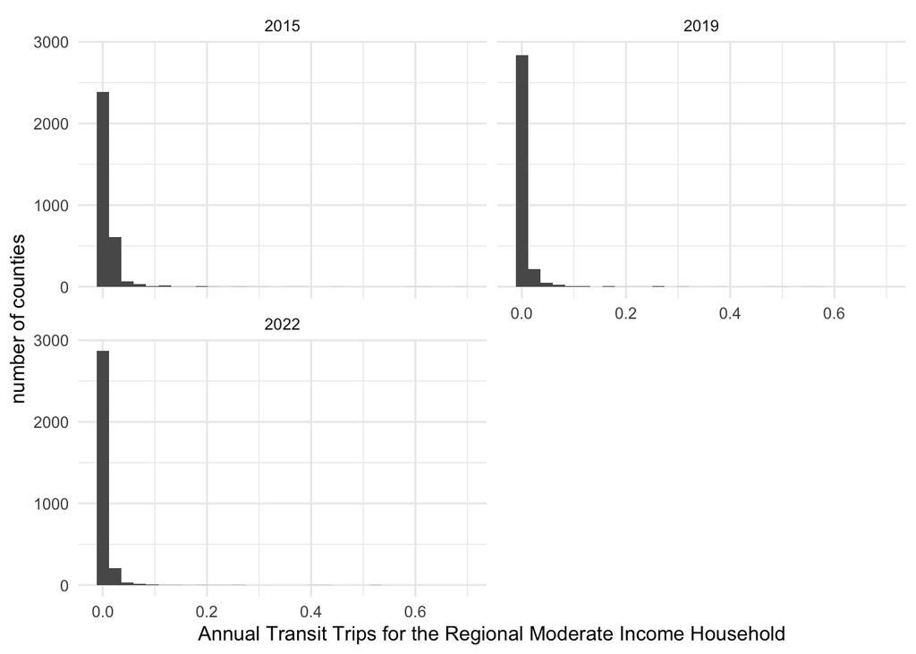

```r
ggplot(transportation_county, aes(x = share_transit_commuter)) +
  geom_histogram() +
  facet_wrap(~ year, nrow = 2) +
  labs(
    x = "Annual Transit Trips for the Regional Moderate Income Household",
    y = "number of counties"
  )
```

Most counties have really low transit trip numbers. Some counties are extreme values.

Look at summary stats

```r
summary(transportation_county$share_transit_commuter)
```

```
   Min. 1st Qu.  Median    Mean 3rd Qu.    Max.    NA's
0.00000 0.00000 0.00000 0.00838 0.01000 0.69000       1
```

Examine extreme values

```r
transportation_county |>
  group_by(year) |>
  slice_max(n = 10, order_by = share_transit_commuter) |>
  select(-population, -share_transportation_cost) |>
  print(n = Inf)
```

```
# A tibble: 30 × 6
# Groups:   year [3]
    year state county blkgrps households share_transit_commuter
   <dbl> <chr> <chr>    <dbl>      <dbl>                  <dbl>
 1  2015 36    061       1091     750419                   0.69
 2  2015 36    005       1132     484902                   0.61
 3  2015 36    047       2049     931786                   0.6
 4  2015 36    081       1706     780644                   0.46
 5  2015 34    017        445     249584                   0.38
 6  2015 06    075        580     353287                   0.36
 7  2015 11    001        450     273390                   0.3
 8  2015 25    025        645     296672                   0.28
 9  2015 42    101       1336     581050                   0.27
10  2015 51    013        181      98441                   0.25
11  2019 36    047       2049     958567                   0.58
```

[output cut: 19 more lines]

### Change

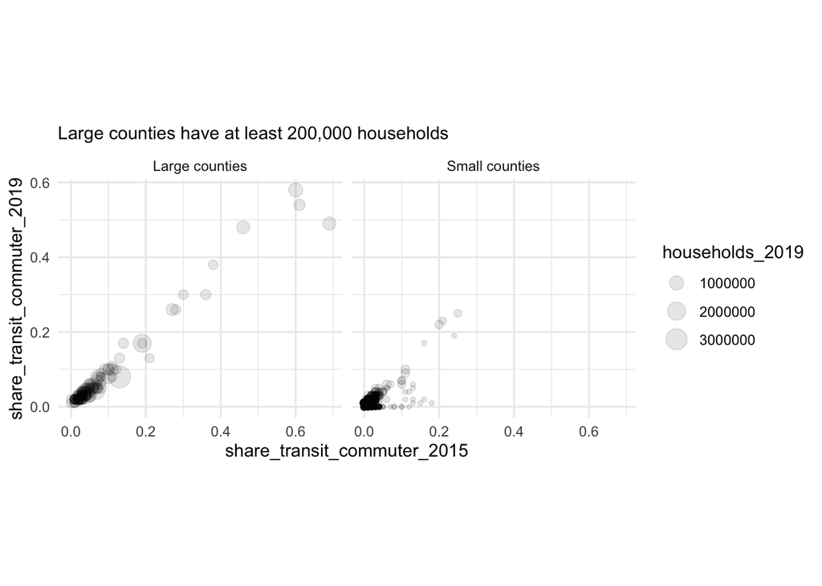

```r
transportation_county |>
  filter(year %in% c(2015, 2019)) |>
  select(state, county, year, households, share_transit_commuter) |>
  pivot_wider(
    names_from = year,
    values_from = c(households, share_transit_commuter)
  ) |>
  mutate(size = if_else(households_2019 > 200000, "Large counties", "Small counties")) |>
  ggplot(aes(share_transit_commuter_2015, share_transit_commuter_2019, size = households_2019)) +
  geom_point(alpha = 0.1) +
  facet_wrap(~ size) +
  coord_equal() +
  labs(subtitle = "Large counties have at least 200,000 households")
```

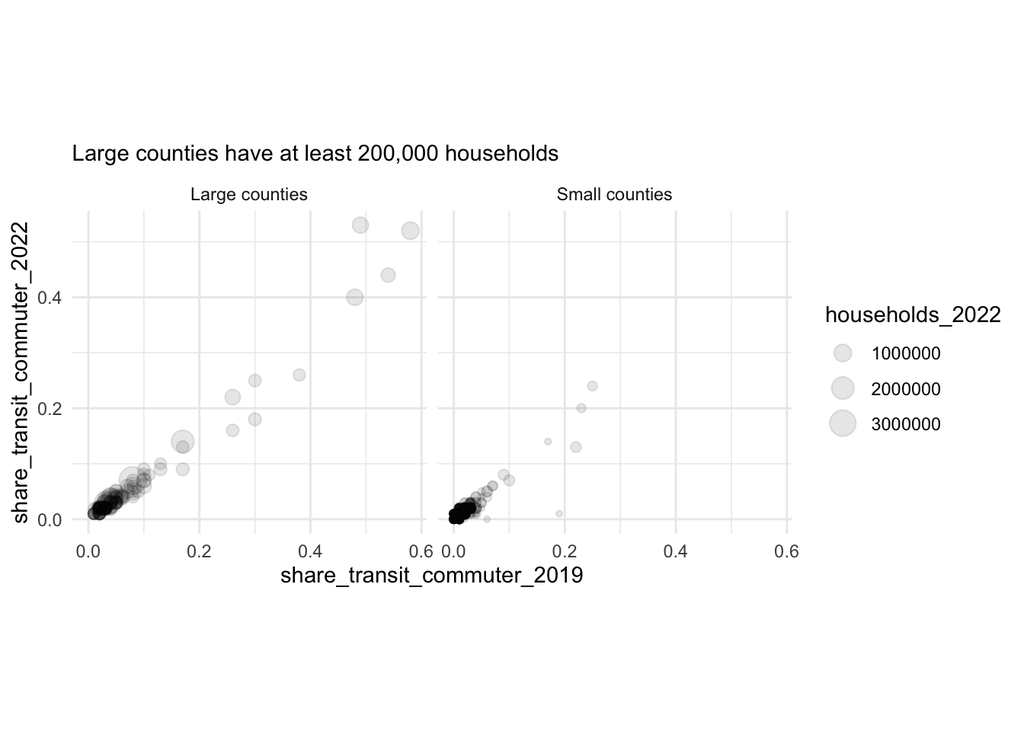

```r
transportation_county |>
  filter(year %in% c(2019, 2022)) |>
  select(state, county, year, households, share_transit_commuter) |>
  pivot_wider(
    names_from = year,
    values_from = c(households, share_transit_commuter)
  ) |>
  mutate(size = if_else(households_2022 > 200000, "Large counties", "Small counties")) |>
  filter(!is.na(households_2022)) |>
  ggplot(aes(share_transit_commuter_2019, share_transit_commuter_2022, size = households_2022)) +
  geom_point(alpha = 0.1) +
  facet_wrap(~ size) +
  coord_equal() +
  labs(subtitle = "Large counties have at least 200,000 households")
```

Examine extreme changes.

```r
transportation_county |>
  group_by(state, county) |>
  mutate(share_transit_commuter_change = share_transit_commuter - lag(share_transit_commuter)) |>
  ungroup() |>
  filter(year %in% c(2019, 2022)) |>
  slice_max(order_by = abs(share_transit_commuter_change), n = 10) |>
  select(year, state, county, households, share_transit_commuter, share_transit_commuter_change) |>
  print(n = Inf)
```

```
# A tibble: 10 × 6
    year state county households share_transit_commuter share_transit_commuter…¹
   <dbl> <chr> <chr>       <dbl>                  <dbl>                    <dbl>
 1  2019 36    061        759460                   0.49                    -0.2
 2  2022 02    016           969                   0.01                    -0.18
 3  2019 02    013           890                   0.01                    -0.17
 4  2019 02    158          1724                   0.02                    -0.14
 5  2019 02    290          1856                   0.01                    -0.14
 6  2019 02    164           421                   0.01                    -0.12
 7  2019 02    282           219                   0                       -0.12
 8  2022 06    075        360842                   0.18                    -0.12
 9  2022 34    017        290054                   0.26                    -0.12
10  2019 02    070          1427                   0.02                    -0.11
# ℹ abbreviated name: ¹share_transit_commuter_change
```

## Cost Quality Control Checks

### Missing Data

```r
transportation_county |>
  filter(is.na(share_transportation_cost))
```

```
# A tibble: 1 × 8
   year state county blkgrps population households share_transit_commuter
  <dbl> <chr> <chr>    <dbl>      <dbl>      <dbl>                  <dbl>
1  2015 48    301          1        117         45                     NA
# ℹ 1 more variable: share_transportation_cost <dbl>
```

Loving County, Texas is missing in 2015.

### Distribution

Use stopifnot to check if all values in `transportation_county` are non-negative

```r
stopifnot(min(transportation_county$share_transportation_cost, na.rm = TRUE) >= 0)
```

Create a histogram plot and summary stats for each dataframe check that all values are non-negative & count missing values examine outliers.

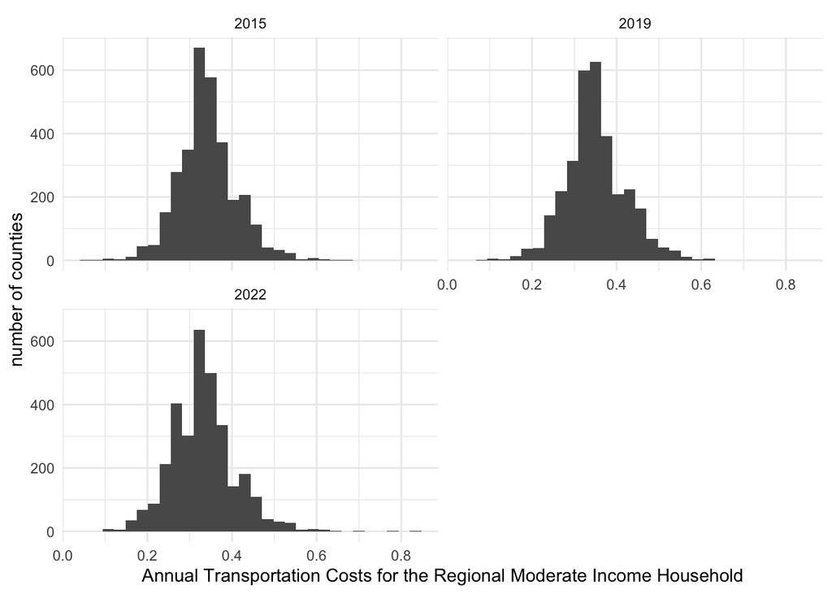

```r
ggplot(transportation_county, aes(x = share_transportation_cost)) +
  geom_histogram() +
  facet_wrap(~ year, nrow = 2) +
  labs(
    x = "Annual Transportation Costs for the Regional Moderate Income Household",
    y = "number of counties"
  )
```

Look at summary stats

```r
summary(transportation_county$share_transportation_cost)
```

```
   Min. 1st Qu.  Median    Mean 3rd Qu.    Max.    NA's
 0.0500  0.3000  0.3400  0.3411  0.3800  0.8300       1
```

Examine extreme values

```r
transportation_county |>
  group_by(year) |>
  slice_max(n = 10, order_by = share_transportation_cost) |>
  select(-population, -share_transit_commuter) |>
  print(n = Inf)
```

```
# A tibble: 33 × 6
# Groups:   year [3]
    year state county blkgrps households share_transportation_cost
   <dbl> <chr> <chr>    <dbl>      <dbl>                     <dbl>
 1  2015 01    119         14       4815                      0.67
 2  2015 21    147         14       6277                      0.65
 3  2015 01    063         10       3201                      0.63
 4  2015 21    189          5       1773                      0.62
 5  2015 13    061          3       1183                      0.61
 6  2015 13    259          5       1731                      0.6
 7  2015 22    107          6       1915                      0.6
 8  2015 28    051         19       6420                      0.6
 9  2015 28    063          7       2545                      0.6
10  2015 35    033          5       1654                      0.6
11  2019 01    105         12       3070                      0.63
```

[output cut: 22 more lines]

### Change

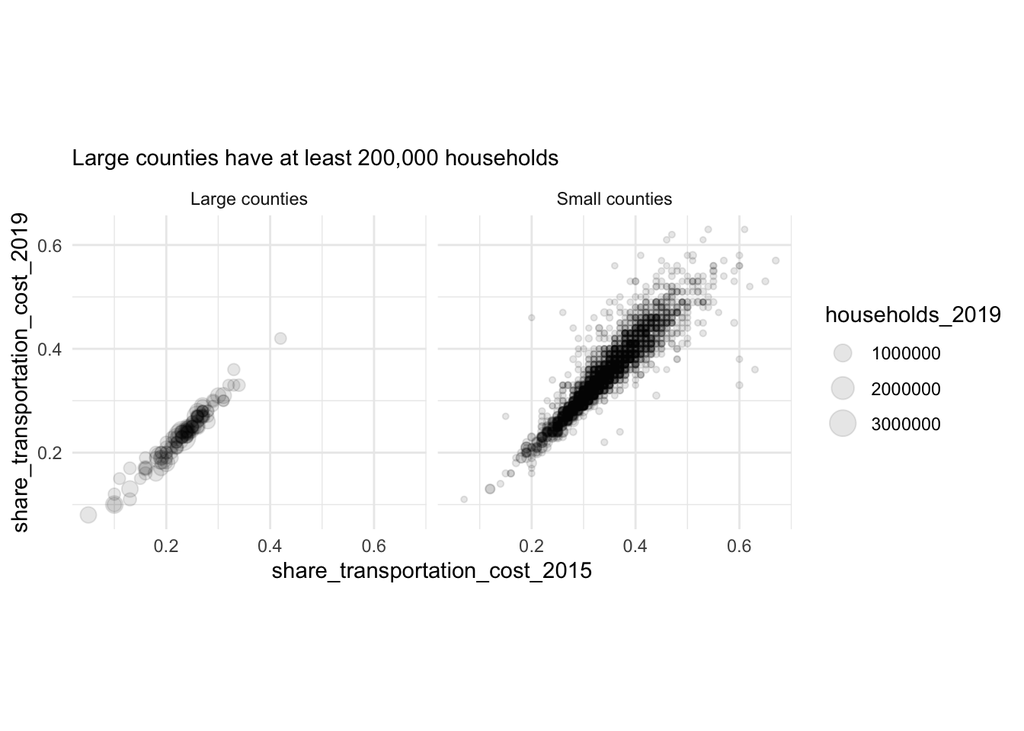

```r
transportation_county |>
  filter(year %in% c(2015, 2019)) |>
  select(state, county, year, households, share_transportation_cost) |>
  pivot_wider(
    names_from = year,
    values_from = c(households, share_transportation_cost)
  ) |>
  mutate(size = if_else(households_2019 > 200000, "Large counties", "Small counties")) |>
  ggplot(aes(share_transportation_cost_2015, share_transportation_cost_2019, size = households_2019)) +
  geom_point(alpha = 0.1) +
  facet_wrap(~ size) +
  coord_equal() +
  labs(subtitle = "Large counties have at least 200,000 households")
```

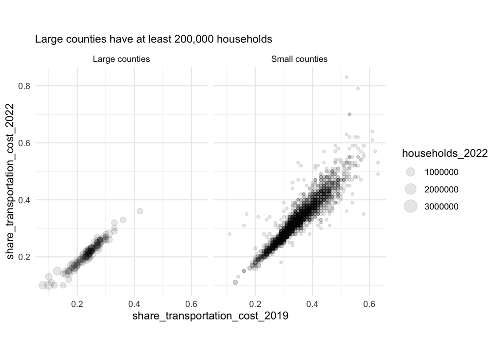

```r
transportation_county |>
  filter(year %in% c(2019, 2022)) |>
  select(state, county, year, households, share_transportation_cost) |>
  pivot_wider(
    names_from = year,
    values_from = c(households, share_transportation_cost)
  ) |>
  filter(!is.na(households_2022)) |>
  mutate(size = if_else(households_2022 > 200000, "Large counties", "Small counties")) |>
  ggplot(aes(share_transportation_cost_2019, share_transportation_cost_2022, size = households_2022)) +
  geom_point(alpha = 0.1) +
  facet_wrap(~ size) +
  coord_equal() +
  labs(subtitle = "Large counties have at least 200,000 households")
```

Examine extreme changes.

```r
transportation_county |>
  group_by(state, county) |>
  mutate(share_transportation_cost_change = share_transportation_cost - lag(share_transportation_cost)) |>
  ungroup() |>
  filter(year %in% c(2019, 2022)) |>
  slice_max(order_by = abs(share_transportation_cost_change), n = 10) |>
  select(year, state, county, households, share_transportation_cost, share_transportation_cost_change) |>
  print(n = Inf)
```

```
# A tibble: 10 × 6
    year state county households share_transportation_c…¹ share_transportation…²
   <dbl> <chr> <chr>       <dbl>                    <dbl>                  <dbl>
 1  2022 28    055           392                     0.83                   0.31
 2  2019 01    063          2951                     0.36                  -0.27
 3  2019 28    051          6188                     0.33                  -0.27
 4  2019 02    282           219                     0.46                   0.26
 5  2022 46    071           735                     0.79                   0.23
 6  2022 48    271          1105                     0.35                  -0.23
 7  2019 13    259          1816                     0.38                  -0.22
 8  2019 38    085          1112                     0.47                   0.21
 9  2019 46    071           858                     0.56                   0.2
10  2022 08    057           645                     0.53                   0.18
# ℹ abbreviated names: ¹share_transportation_cost,
#   ²share_transportation_cost_change
```

## Data Quality Marker

We used to use `B00002_001`, which is the UNWEIGHTED SAMPLE HOUSING UNITS for the data quality measure. This variable was [discontinued](https://www.census.gov/programs-surveys/acs/technical-documentation/user-notes/2020-05.html) after 2018. H+T doesn’t report margins of error. Median household income (`B19013_001`) is an important predictor in H+T’s models so we use the coefficient of variation for median household income to determine data quality.

```r
acs_sample_size <- bind_rows(
  `2015` = get_acs(
    geography = "county",
    variables = c("B00002_001", "B19013_001"),
    year = 2015,
    survey = "acs5",
    output = "wide"
  ),
  `2019` = get_acs(
    geography = "county",
    variables = "B19013_001",
    year = 2019,
    survey = "acs5",
    output = "wide"
  ),
  `2022` = get_acs(
    geography = "county",
    variables = "B19013_001",
    year = 2022,
    survey = "acs5",
    output = "wide"
  ),
  .id = "year"
) |>
  rename(
    sample_size = B00002_001E,
    med_hh_income = B19013_001E,
    med_hh_income_moe = B19013_001M,
  ) |>
  mutate(
    year = as.numeric(year),
    state = str_sub(GEOID, start = 1, end = 2),
    county = str_sub(GEOID, start = 3, end = 5)
  )
```

```r
acs_sample_size <- acs_sample_size |>
  # turn a 90% MOE into a standard error
  mutate(med_hh_income_se = med_hh_income_moe / qnorm(0.95)) |>
  # calculate the coefficient of variation
  mutate(med_hh_income_cv = med_hh_income_se / med_hh_income) |>
  select(-med_hh_income, -med_hh_income_se, -med_hh_income_moe)
```

```r
transportation_county <- left_join(
  transportation_county,
  acs_sample_size,
  by = c("year", "state", "county")
)
```

Determine data quality cutoffs based on number of observations (all at the HH level for these values).

```r
summary(transportation_county$med_hh_income_cv)
```

```
    Min.  1st Qu.   Median     Mean  3rd Qu.     Max.     NA's
0.002921 0.022684 0.036113 0.044367 0.056391 0.477589        2
```

Elsewhere, we use 0.2 and 0.4 as cutoffs for the coefficient of variation. These metrics contain extra uncertainty from other variables and modelings, so we 0.1 and 0.3 as cutoffs.

```r
transportation_county <- transportation_county |>
  mutate(
    share_transit_commuter_quality = case_when(
      med_hh_income_cv < 0.1 ~ 1,
      med_hh_income_cv < 0.3 ~ 2,
      TRUE ~ 3
    ),
    share_transportation_cost_quality  = case_when(
      med_hh_income_cv < 0.1 ~ 1,
      med_hh_income_cv < 0.3 ~ 2,
      TRUE ~ 3
    )
  )
```

Suppress data quality flags if the metric is missing.

```r
transportation_county <- transportation_county |>
  mutate(
    share_transit_commuter_quality =
      if_else(is.na(share_transit_commuter), NA, share_transit_commuter_quality),
    share_transportation_cost_quality =
      if_else(is.na(share_transportation_cost), NA, share_transportation_cost_quality),
  )
```

Examine the data quality flags.

```r
count(transportation_county, year, share_transit_commuter_quality)
```

```
# A tibble: 9 × 3
   year share_transit_commuter_quality     n
  <dbl>                          <dbl> <int>
1  2015                              1  3035
2  2015                              2   106
3  2015                             NA     1
4  2019                              1  2982
5  2019                              2   158
6  2019                              3     2
7  2022                              1  2879
8  2022                              2   259
9  2022                              3     6
```

```r
count(transportation_county, year, share_transportation_cost_quality)
```

```
# A tibble: 9 × 3
   year share_transportation_cost_quality     n
  <dbl>                             <dbl> <int>
1  2015                                 1  3035
2  2015                                 2   106
3  2015                                NA     1
4  2019                                 1  2982
5  2019                                 2   158
6  2019                                 3     2
7  2022                                 1  2879
8  2022                                 2   259
9  2022                                 3     6
```

Confirm there isn’t a mismatch between missing values and missing quality flags.

```r
stopifnot(
  transportation_county |>
    filter(
      (!is.na(share_transit_commuter) & is.na(share_transit_commuter_quality)) |
        (!is.na(share_transportation_cost) & is.na(share_transportation_cost_quality))
    ) |>
    nrow() == 0
)

stopifnot(
  transportation_county |>
    filter(
      (is.na(share_transit_commuter) & !is.na(share_transit_commuter_quality)) |
        (is.na(share_transportation_cost) & !is.na(share_transportation_cost_quality))
    ) |>
    nrow() == 0
)
```

## Test Final File

Keep variables of interest and order them appropriately.

```r
final_data <- transportation_county |>
  select(year, state, county, share_transit_commuter, share_transit_commuter_quality, share_transportation_cost, share_transportation_cost_quality) |>
  arrange(year, state, county)
```

Run the evaluation function.

```r
evaluate_final_data(
  exp_form_path = here("10a_final-evaluation", "evaluation_form_transportation.csv"),
  data = final_data,
  geography = "county",
  confidence_intervals = FALSE
)
```

```
[1] "This data passes all tests!"
```

Write the final data.

```r
final_data |>
  write_csv(
    here("06_neighborhoods",
         "Transportation",
         "final",
         "transportation_all_county.csv")
  )
```